# 二进制加法

Gao Jian

2020/11/29

这次作业里面二进制加法似乎让大家煞费苦心……这里提供一些思路供大家参考。

## 思路一：使用数组

大多数同学选择了这种方法，就是把两行输入写到字符串里面，重新排列字符串使得最低位可以对齐。之后从低位到高位依次相加并处理进位。这里抛砖引玉，给出一种实现方法，可能做法比较傻，但思路简单清晰。

参考下图

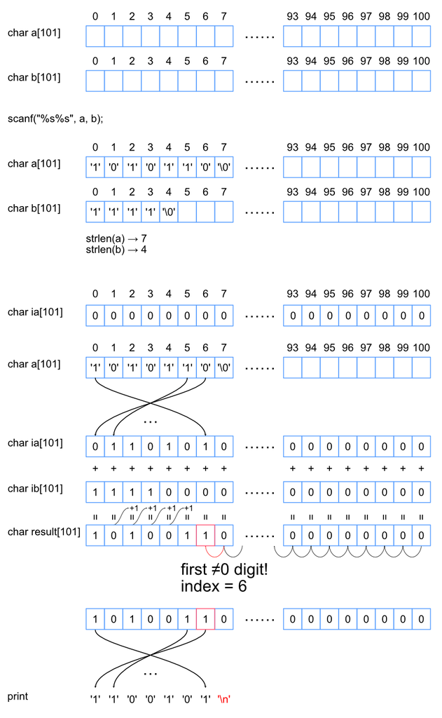

fig1

注意数组a和b要比100稍微大一点，因为读入字符串后会在最后加一个终止符’\0’，要保证这个终止符也不会越界。

再搞两个字符数组ia和ib，把每一位个位置都设成0.

然后根据a和b的长度，把字符换算成数字填入数组ia和ib（如果是字符’0’则填写数字0，如果是字符’1’则填写数字1）. 注意数组下标，把数组反过来填写，这样ia和ib都对齐到左边了。

然后从左到右计算加法，并考虑进位。

输出时，先从右到左找找看result的哪一位是第一个不为0的位，就从这里开始从右向左输出。

代码如下

```c
#include <stdio.h>
#include <string.h>

//用于读取，将读取到的字符串解码并反向存入target指针所指向的内存位置
void ReadBin(char* target){
    char tmp[101];
    int len;
    int i;
    //读取前先将target初始化，所有字符设为0
    for(i = 0; i < 101; i++){
        target[i] = 0;
    }
    scanf("%s", tmp);
    len = strlen(tmp);
    for(i = 0; i < len; i++){
        //如果原字符数组中内容是'1'则填入1，否则不填
        //由于前面已经初始化为0了，就不必专门填写0的位了
        if(tmp[len-1-i]=='1'){
            target[i] = 1;
        }
    }
}

//a <- a+b
//两个101位的字符数组相加
//观察到加法结束后没有必要保留a的原始值，故直接将结果存入a
void AddBin(char* a, char* b){
    int i;//循环变量
    int c = 0;//进位标志
    for(i = 0; i < 101; i++){
        a[i] = a[i] + b[i] + c;
        c = a[i]/2;
        a[i] = a[i]%2;
    }
}

//输出指针a位置的二进制
void PrintBin(char* a){
    int i = 100;
    //开始，如果a[i]是0，则i减一（看左边一位）。直到a[i]!=1为止。
    while(a[i]==0){
        i--;
    }
    //从右向左一位一位输出
    while(i>=0){
        if(a[i] == 0){
            printf("0");
        }else{
            printf("1");
        }
        i--;
    }
    printf("\n");
}

int main(){
    int n;
    char a[101], b[101];
    scanf("%d", &n);
    //循环n次，每次读入两行，求和，再输出一行
    do{
        n--;
        ReadBin(a);
        ReadBin(b);
        AddBin(a,b);
        PrintBin(a);
    }while(n>0);
}
```

## 思路二：一个long long存不下就用两个

题目要求中，最大数组长度是100。考虑到long long类型的宽度是64，那么两个long long就足够存储了。

读取的时候就像手写数字一样：

> 例如写一万三千二百零四

|  | 纸上的字 | 大小 |
| --- | --- | --- |
| 1 | 1 | 一 |
| 2 | 13 | 十三 |
| 3 | 132 | 一百三十二 |
| 4 | 1320 | 一千三百二十 |
| 5 | 13204 | 一万三千二百零四 |

注意到每次多写一个数字的时候，相当于之前一步得到的数字乘十再加上新的数字。

二进制也是同理，每次写下一位0或1，当写下一位的时候，将之前得到的数字乘二（或者说向左移动一位），然后把新的一位加上去。

考虑到最大可能有100位数字，不妨将最低的50位保存在第一个long long中，高50位保存在第二个long long中，各分一半，简单粗暴。

这样，读取的时候就需要注意一点，当低位部分(al)的第51位出现1的时候应当把这个1加到高位(ah)中。

读取方式如下图

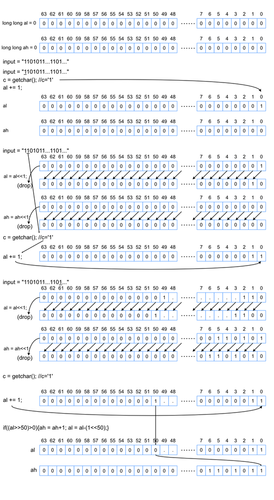

fig2

这样加法就很简单了，直接两个数的低50位（也就是al的部分）相加，高位也相加。加完之后再判断一下al的第51位有没有出现进位，如果出现了进位的话，操作同上，直接将这一位减掉，然后ah加上1.

输出的时候可以采用类似上面思路一的输出方式，就不赘述了。

代码如下：

```c
#include <stdio.h>
//读取二进制到ah和al指向的内存空间中。ah和al如上文所描述，是两个long long
void ReadBin(unsigned long long *ah, unsigned long long *al){
    char c;
    //先置0
    *ah = 0;
    *al = 0;
    while(1){
        //不断读入字符
        //如果是换行符\n则结束循环
        //如果是'0'就只是al和ah都左移一位
        //如果是'1'就在左移后还要给al加上1
        //注意还要判断一下al的第51位是不是1，是的话要向ah进位
        c = getchar();
        if(c == '\n'){
            break;
        }else if(c == '0'){
            *al = (*al) << 1;
            *ah = (*ah) << 1;
            if(((*al)>>50)>0){
                *al = (*al) - ((unsigned long long)1<<50);
                *ah = (*ah) + 1;
            }
        }else if(c == '1'){
            *al = (*al) << 1;
            *al = (*al) + 1;
            *ah = (*ah) << 1;
            if(((*al)>>50)>0){
                *al = (*al) - ((unsigned long long)1<<50);
                *ah = (*ah) + 1;
            }
        }
    }
}

//(ah, al) = (ah, al) + (bh, bl)
//观察到加法结束后没有必要保留a的原始值，故直接将结果存入a
void AddBin(unsigned long long *ah, unsigned long long *al, unsigned long long *bh, unsigned long long *bl){
    //直接低位加低位，高位加高位
    *al = (*al) + (*bl);
    *ah = (*ah) + (*bh);
    //加完后要判断一下是否需要由al向ah进位
    if(((*al)>>50)>0){
        *al = (*al) - ((unsigned long long)1<<50);
        *ah = (*ah) + 1;
    }
}

//输出二进制
void PrintBin(unsigned long long ah, unsigned long long al){
    int i;
    //高位ah为0是，只输出al部分
    if(ah == 0){
        //从第50位开始看（右移49位则第50位恰好在al的最低位）
        i = 49;
        //如果是0则看下一位，直到遇到第一个1
        while(((al>>i)&1) == 0){
            i--;
        }
        //从这里开始一位一位看，并根据这一位打印1或0
        while(i >= 0){
            printf("%llu", (al>>i)&1);
            i--;
        }
    //若高位ah不为0，则从ah开始打印
    //思路一样，只是al无论前面是否是0都要全部打印
    //考虑到两个100位数字相加可能得到101位数，因此高位ah从第51位开始判断
    }else{
        i = 50;
        while(((ah>>i)&1) == 0){
            i--;
        }
        while(i >= 0){
            printf("%llu", (ah>>i)&1);
            i--;
        }
        i = 49;
        while(i >= 0){
            printf("%llu", (al>>i)&1);
            i--;
        }
    }
    printf("\n");
}

int main(){
    unsigned long long ah, al, bh, bl;
    int n;
    scanf("%d\n", &n);
    while(n>0){
        ReadBin(&ah, &al);
        ReadBin(&bh, &bl);
        AddBin(&ah, &al, &bh, &bl);
        PrintBin(ah, al);
        n--;
    }
}
```